# From Bean to Cup: A Lifecycle and Equity Analysis of Coffee Sustainability

LCA methodology, value chain inequity, and the limits of voluntary certification

LCA

ESG

Supply Chain

Sustainability

Coffee

Value Chain

Author

Natasha Kabuka

Published

January 1, 2025

## Abstract

Coffee is the world’s second most traded commodity, with global production exceeding 10 billion kilograms annually and European consumption driven by Germany’s per capita intake of 164 litres per year. This paper applies a lifecycle assessment (LCA) framework to evaluate coffee production and consumption through three sustainability pillars: environmental, economic, and social. Using a functional unit of 1 kg of green coffee beans, it compares conventional and sustainable farming practices across cultivation, processing, distribution, and consumption stages, identifying environmental hotspots and structural equity gaps.

## 1. Why Lifecycle Assessment

Coffee’s sustainability is often assessed through company-level ESG ratings or voluntary certification labels. Both approaches have structural limits. ESG ratings evaluate performance at the firm level using opaque, aggregated methodologies that can obscure product-level impact variation. Certification labels (Fairtrade, Rainforest Alliance, 4C) assess compliance with scheme-specific standards but do not provide quantitative lifecycle data or transparent comparability across schemes.

Lifecycle assessment offers something different: a process-based, stage-by-stage quantification of environmental impacts per functional unit, from agricultural inputs through to end-of-life disposal. This transparency makes it possible to identify exactly where emissions are concentrated, how different farming practices alter that distribution, and where interventions would produce the largest reductions.

The chosen functional unit for this analysis is 1 kg of green coffee beans. Per-cup consumption data (110 ml lungo, sourced from the Nestlé-Nespresso LCA by Quantis, 2024) is included as a supplementary lens on European consumer-stage impacts, though it is not directly comparable to upstream figures. The system boundary follows a cradle-to-grave model: cultivation through end-of-life waste.

## 2. Environmental Analysis

### 2.1 GHG Emissions by Lifecycle Stage

The emissions data below are drawn from Hasan, Roy and Abassi (2024), with transport figures from Nab and Maslin (2020). All figures are in kg CO2-equivalent per kg of green coffee under conventional practices.

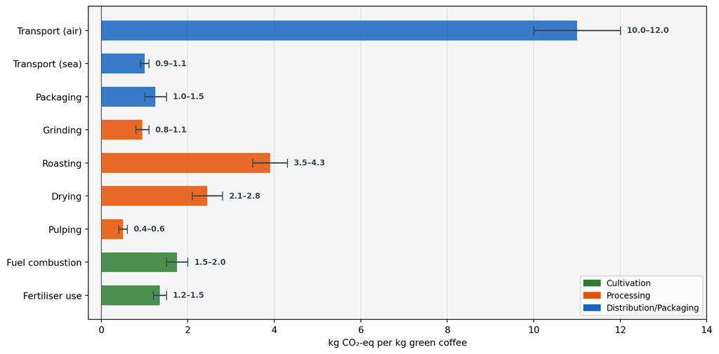

Figure 1: GHG emissions by lifecycle stage, conventional coffee (Hasan, Roy & Abassi, 2024)

Roasting (3.5–4.3 kg CO2-eq) and drying (2.1–2.8 kg CO2-eq) dominate the processing stage, driven by fossil fuel dependency in industrial drying systems and natural gas use in roasting. This finding challenges a consumer-level assumption: buying certified coffee addresses cultivation-stage impacts but leaves processing emissions largely unchanged, since certification schemes do not typically govern energy sources at roasting facilities.

The transport mode comparison is instructive. Sea freight produces 0.9–1.1 kg CO2-eq/kg; air freight exceeds 10 kg CO2-eq/kg — an order-of-magnitude difference that makes transport mode one of the highest-leverage interventions available in the distribution stage.

### 2.2 Conventional vs. Sustainable Practices

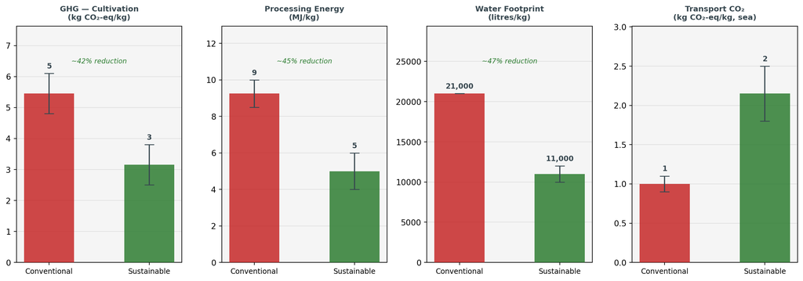

Figure 2: Key environmental metrics: conventional vs. sustainable/organic coffee

## 3. The Economics of Coffee: A Value Chain Equity Problem

### 3.1 Who captures value?

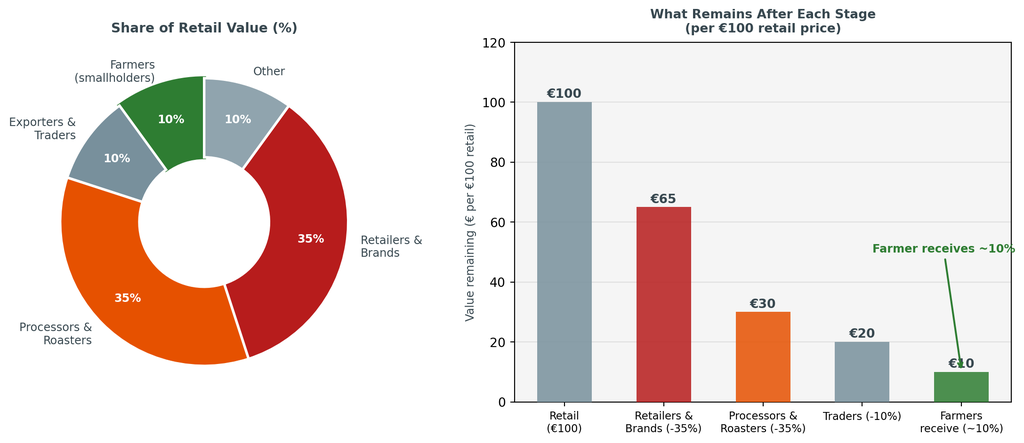

Figure 3: Distribution of retail coffee value across supply chain actors (ICO, 2023)

The global coffee market was valued at over $130 billion in 2023 (ICO, 2023). Farmers — the 12.5 million smallholders who grow the crop — receive approximately 10% of the retail value that crop eventually commands. Roasters and retailers capture roughly 70%. Certification premiums — where they exist — operate within this structure, adding a modest increment to farmgate prices without altering the underlying distribution.

The structural consequence is visible in the data: in eight of the ten largest producing countries, farmgate prices periodically fall below the cost of production (ICO, 2023; Nestlé, 2024). When that happens, the farmer bears the loss. When prices rise, the gains accrue disproportionately downstream. Certification schemes do not change this structure; they improve practice within it.

## 4. Company Scorecard: Claims vs. Verifiable Outcomes

The three largest coffee companies — Nestlé, Starbucks, and JDE Peet’s — collectively account for a substantial share of global roasted coffee volume and are the most visible proponents of certified sustainable sourcing. The scorecard below compares their stated commitments against independently verifiable outcomes from 2023–2024 reporting.

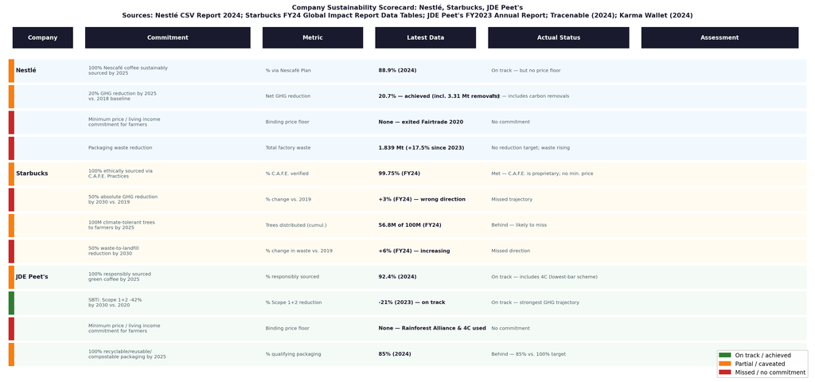

Figure 4: Company sustainability scorecard: Nestlé, Starbucks, JDE Peet’s (2023-24)

## 5. Why Certification Schemes Cannot Solve This

Voluntary certification schemes represent the coffee sector’s primary market-based response to its sustainability failures. Fairtrade, Rainforest Alliance, Organic, and 4C are the most widely used, covering progressively broader shares of global supply. The evidence presented in this paper suggests that the structural constraint of VCS is not their design quality — it is what they are not designed to do.

VCS operate at the level of farming practice: they certify whether shade-grown methods are used, whether agrochemicals are applied responsibly, whether workers have access to training. These are genuine and measurable improvements. Hasan et al. (2024) confirm that certified farms perform better across nearly all environmental impact categories compared to conventional equivalents. The Rubio-Jovel (2022) analysis similarly finds that certified farmers report marginally better incomes and training opportunities than non-certified peers.

The structural problem is that these improvements occur within a price architecture that VCS do not govern. With the exception of Fairtrade — which sets a minimum floor price and a verified premium paid directly to producer cooperatives — no major certification scheme commits the buyer to a minimum purchase price. The buyer pays the market price (or a discretionary premium) for certified coffee and absorbs the reputational benefit of the certification label. The farmer absorbs the cost of meeting certification requirements: infrastructure investment, documentation practices, cooperative membership, and ongoing compliance — costs that can be prohibitive without external support, and that provide no income guarantee if market prices fall below production cost (Hasan et al., 2024).

The Coffee Brew Index and the Coffee Barometer (2023) both document a consistent gap between corporate sustainability claims and measurable systemic progress. Major companies set ambitious 2030 targets while absolute emissions, waste volumes, and farmgate price instability persist. The growing sophistication of sustainability reporting — more detailed disclosures, more SDG references, more programme descriptions — has not been accompanied by commensurate improvement in the outcomes those reports are intended to address.

This pattern has a name in sustainability governance literature: it is the displacement of structural intervention by risk management. Companies invest in certification coverage, farmer training programmes, and reporting infrastructure to manage regulatory exposure, reputational risk, and supply chain continuity. These investments are not insincere — they produce real improvements at the margin. But their architecture is designed to be compatible with continued growth in purchasing volume, which drives absolute impacts upward even as intensity metrics improve. Starbucks’ 3% absolute emissions increase above its 2019 baseline, against a 2030 target of 50% reduction, while 99.75% of its coffee is C.A.F.E. certified, is the most direct illustration of this dynamic.

Fairtrade’s exit from Nestlé’s KitKat supply chain in 2020 — the one scheme that did set a price floor and a verified premium, costing farmers in Côte d’Ivoire £2 million in annual premiums — and its replacement with Rainforest Alliance (no price floor, no verified premium) illustrates where the sector’s structural orientation lies. The certifications that persist are those compatible with the buyer’s pricing power. The one that was not compatible with it was removed.

Closing the living income gap documented by the KIT Institute, the farmgate share problem identified by the ICO, and the persistent labor rights violations noted by the ILO would require interventions that operate at the price level: minimum purchase price commitments, mandatory living income procurement policies, or regulatory price floors enforced at the import stage. The EU Deforestation Regulation represents a step toward regulatory intervention in supply chain standards, though its mechanism targets land use rather than income distribution. CSRD’s double materiality framework will eventually require companies to disclose impacts on farmer livelihoods in quantified terms, creating accountability pressure for the outcome dimension that self-reported certification coverage currently avoids.

## 6. SDG Alignment: Systemic Gap

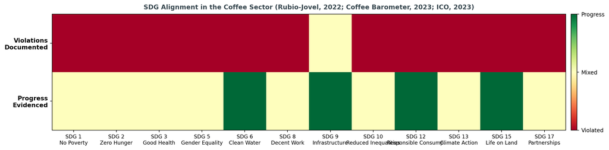

Figure 5: SDG alignment in the coffee sector: documented violations vs. evidenced progress

The SDG alignment matrix surfaces the systemic character of coffee’s sustainability gap. Violations are documented across 11 of 12 relevant SDGs; evidenced progress exists in only 4, and in each case that progress is partial and contested. SDG 17 (Partnerships) is the most significant absence: the governance gap between Global North consumption and Global South production — the structural asymmetry at the core of this analysis — is precisely what a genuine partnership framework would need to address.

## 7. EU Consumption and Demand-Side Responsibility

Germany’s per capita coffee consumption of 164 litres annually (ICO, 2022–2023) places it among the world’s highest-consuming markets. European consumption patterns amplify the impacts identified in this analysis: single-serve pods, takeaway culture, and plastic-lined disposable cups contribute disproportionately to the waste and emissions concentrated in the consumption stage.

The EU Deforestation Regulation, effective from 2025, requires proof of deforestation-free supply chains for key commodities including coffee. This represents a meaningful regulatory intervention in supply chain standards but targets land use rather than income distribution. Its principal risk — documented by the Coffee Barometer (2023) — is that compliance pressure may cause large buyers to withdraw from high-risk smallholder regions, marginalising the farmers most in need of market access.

The ICO Circular Economy Report (2022–2023) identifies a practical roadmap for demand-side intervention: regenerative agriculture incentives, waste valorisation (spent grounds into bioenergy or compost), packaging redesign under R9 circular economy principles, localised roasting and distribution to reduce transport emissions, and consumer education campaigns targeting high-impact behaviours such as pod use and dairy choice. These interventions are available and technically feasible. Their implementation requires the kind of regulatory and pricing commitment that voluntary action has not produced.

## References

Chapagain, A.K. and Hoekstra, A.Y. (2007). “The Water Footprint of Coffee and Tea Consumption in the Netherlands.” *Ecological Economics* 64(1): 109–118. https://doi.org/10.1016/j.ecolecon.2007.02.022

Coffee Barometer (2023). *Coffee Barometer 2023.* https://coffeebarometer.org

Hasan, Y., Roy, P. and Abassi, B. (2024). “Comparative Life Cycle Assessment (LCA) in the Agri-Food Industry, Focusing on Organic and Conventional Coffee.” *Sustainability* 16(24): 10819. https://www.mdpi.com/2071-1050/16/24/10819

ICO — International Coffee Organization (2022–2023). *ICO Coffee Circular Economy Report.* https://hdl.handle.net/10568/131997

ICO — International Coffee Organization (2023). *Coffee Development Report 2022–23.* https://ico.org/coffee-development-report-2/

JDE Peet’s (2024). *Full-Year Results 2023.* https://www.jdepeets.com/news-container/jde-peets-reports-full-year-results-2023-2832441/

Karma Wallet (2024). “Starbucks Sustainability: The Good & The Bad.” https://karmawallet.io/blog/2024/07/starbucks-sustainability-the-good-the-bad/

Klim (2024). “Overcoming Challenges in Insetting Projects.” https://www.klim.eco/en/blog/herausforderungen-in-insetting-projekten-ueberwinden

Nab, H. and Maslin, M. (2020). *How Bad Are Bananas? The Carbon Footprint of Everything.* London: Profile Books.

Nestlé (2024). *Creating Shared Value and Sustainability Report 2023.* https://www.nestle.com/sites/default/files/2024-02/creating-shared-value-sustainability-report-2023-en.pdf

Nestlé (2025). *Sustainability Performance Data 2024.* Nestlé S.A.

Nestlé Nespresso (2023). *EU LCA Infographic.* https://nestle-nespresso.com/sites/site.prod.nestle-nespresso.com/files/NN_EU_LCA_Infographic_Jan%202023_1.pdf

Rubio-Jovel, R. (2022). “Voluntary Sustainability Standards in Coffee: Progress, Limitations and Trade Impacts.” *International Journal of Development Policy and Practice* 6(4): 82–99.

Starbucks (2025). *Fiscal 2024 Global Impact Report.* https://about.starbucks.com/uploads/2025/05/Starbucks-Fiscal-2024-Global-Impact-Report.pdf

Starbucks (2025). *Fiscal 2024 Global Impact Report — Data Tables.* https://about.starbucks.com/uploads/2025/05/Starbucks-Fiscal-2024-Global-Impact-Report-Data-Tables.pdf

Tracenable (2024). *Starbucks GHG Emissions Data.* https://tracenable.com/company/starbucks/ghg-emissions